# Peer graded assignment

12/25/2021

## Title

Exploring the NOAA Storm Database: US Severe Weather impacts on Health and Economics The goal of this assignment is to explore the NOAA Storm Database and answer questions about how severe weather events.The NOAA Storm Database is to be used to address the questions.The analysis consist of figures, and other summaries by using R to support the analysis.

## Synopsis

The NOAA database tracks characteristics of major storms and weather events in the United States, including when and where they occur, as well as estimates of any fatalities, injuries, and property damage. This shows how severe weather events can cause both public health and economic instabilities.

## Data Processing

```r
storm <- read.table("repdata_data_StormData.csv", sep=",", header=TRUE)
Main_data <- storm
Main_data$BGN_DATE <- strptime(storm$BGN_DATE, "%m/%d/%Y %H:%M:%S")
Main_data <- subset(Main_data, BGN_DATE > "1995-12-31")
```

## Selecting Useful Data for this Analysis after study of NOAA Documentation by transforming data elements

```r
Main_data <- subset(Main_data, select = c(EVTYPE, FATALITIES, INJURIES, PROPDMG, PROPDMGEXP, CROPDMG, CROPDMGEXP))
#cleaning event types names
Main_data$EVTYPE <- toupper(Main_data$EVTYPE)
# eliminating zero data
Main_data <- Main_data[Main_data$FATALITIES !=0 |
                       Main_data$INJURIES !=0 |
                       Main_data$PROPDMG !=0 |
                       Main_data$CROPDMG !=0, ]
```

#Population health data processing

```r
Health_data <- aggregate(cbind(FATALITIES, INJURIES) ~ EVTYPE, data = Main_data, FUN=sum)
Health_data$PEOPLE_LOSS <- Health_data$FATALITIES + Health_data$INJURIES
Health_data <- Health_data[order(Health_data$PEOPLE_LOSS, decreasing = TRUE), ]
Top10_events_people <- Health_data[1:10,]
print(Top10_events_people)
```

```
##                EVTYPE FATALITIES INJURIES PEOPLE_LOSS
## 149           TORNADO       1511    20667       22178
## 39     EXCESSIVE HEAT       1797     6391        8188
## 48              FLOOD        414     6758        7172
## 107         LIGHTNING        651     4141        4792
## 153         TSTM WIND        241     3629        3870
## 46        FLASH FLOOD        887     1674        2561
## 146 THUNDERSTORM WIND        130     1400        1530
## 182      WINTER STORM        191     1292        1483
## 69               HEAT        237     1222        1459
## 88  HURRICANE/TYPHOON         64     1275        1339
```

#transforming letters and symbols to numbers for wconomic data processing

```r
Main_data$PROPDMGEXP <- gsub("[Hh]", "2", Main_data$PROPDMGEXP)
Main_data$PROPDMGEXP <- gsub("[Kk]", "3", Main_data$PROPDMGEXP)
Main_data$PROPDMGEXP <- gsub("[Mm]", "6", Main_data$PROPDMGEXP)
Main_data$PROPDMGEXP <- gsub("[Bb]", "9", Main_data$PROPDMGEXP)
Main_data$PROPDMGEXP <- gsub("\\+", "1", Main_data$PROPDMGEXP)
Main_data$PROPDMGEXP <- gsub("\\?|\\-|\\ ", "0",  Main_data$PROPDMGEXP)
Main_data$PROPDMGEXP <- as.numeric(Main_data$PROPDMGEXP)

Main_data$CROPDMGEXP <- gsub("[Hh]", "2", Main_data$CROPDMGEXP)
Main_data$CROPDMGEXP <- gsub("[Kk]", "3", Main_data$CROPDMGEXP)
Main_data$CROPDMGEXP <- gsub("[Mm]", "6", Main_data$CROPDMGEXP)
Main_data$CROPDMGEXP <- gsub("[Bb]", "9", Main_data$CROPDMGEXP)
Main_data$CROPDMGEXP <- gsub("\\+", "1", Main_data$CROPDMGEXP)
Main_data$CROPDMGEXP <- gsub("\\-|\\?|\\ ", "0", Main_data$CROPDMGEXP)
Main_data$CROPDMGEXP <- as.numeric(Main_data$CROPDMGEXP)

Main_data$PROPDMGEXP[is.na(Main_data$PROPDMGEXP)] <- 0
Main_data$CROPDMGEXP[is.na(Main_data$CROPDMGEXP)] <- 0
```

#creating total damage values

```r
library(dplyr)
Main_data <- mutate(Main_data,
                    PROPDMGTOTAL = PROPDMG * (10 ^ PROPDMGEXP),
                    CROPDMGTOTAL = CROPDMG * (10 ^ CROPDMGEXP))
#analyzing
Economic_data <- aggregate(cbind(PROPDMGTOTAL, CROPDMGTOTAL) ~ EVTYPE, data = Main_data, FUN=sum)
Economic_data$ECONOMIC_LOSS <- Economic_data$PROPDMGTOTAL + Economic_data$CROPDMGTOTAL
Economic_data <- Economic_data[order(Economic_data$ECONOMIC_LOSS, decreasing = TRUE), ]
Top10_events_economy <- Economic_data[1:10,]
print(Top10_events_economy)
```

```
##                EVTYPE PROPDMGTOTAL CROPDMGTOTAL ECONOMIC_LOSS
## 48              FLOOD 143944833550   4974778400  148919611950
## 88  HURRICANE/TYPHOON  69305840000   2607872800   71913712800
## 141       STORM SURGE  43193536000         5000   43193541000
## 149           TORNADO  24616945710    283425010   24900370720
## 66               HAIL  14595143420   2476029450   17071172870
## 46        FLASH FLOOD  15222203910   1334901700   16557105610
## 86          HURRICANE  11812819010   2741410000   14554229010
## 32            DROUGHT   1046101000  13367566000   14413667000
## 152    TROPICAL STORM   7642475550    677711000    8320186550
## 83          HIGH WIND   5247860360    633561300    5881421660
```

## Results

graph one can concludes that TORNADOS, EXCESSIVE HEAT and FLOOD are the main contributors to deaths and injuries out of all event types of weather events.

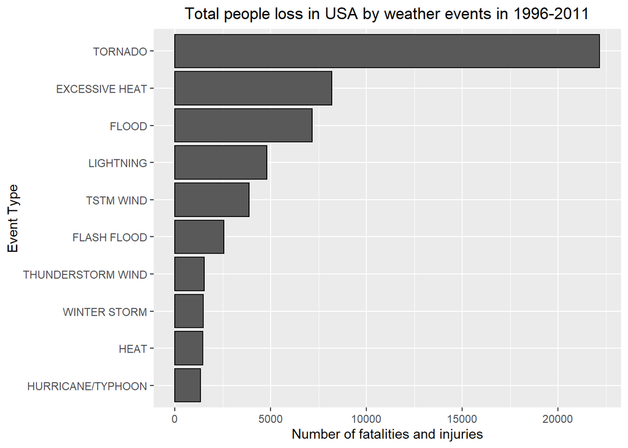

```r
#plotting health loss
library(ggplot2)
g <- ggplot(data = Top10_events_people, aes(x = reorder(EVTYPE, PEOPLE_LOSS), y = PEOPLE_LOSS))
g <- g + geom_bar(stat = "identity", colour = "black")
g <- g + labs(title = "Total people loss in USA by weather events in 1996-2011")
g <- g + theme(plot.title = element_text(hjust = 0.5))
g <- g + labs(y = "Number of fatalities and injuries", x = "Event Type")
g <- g + coord_flip()
print(g)
```

graph two concludes that FLOOD, HURRICANE/TYPHOON and STORM SURGE are the main contributors to severe economic consequences out of all event types of weather events.

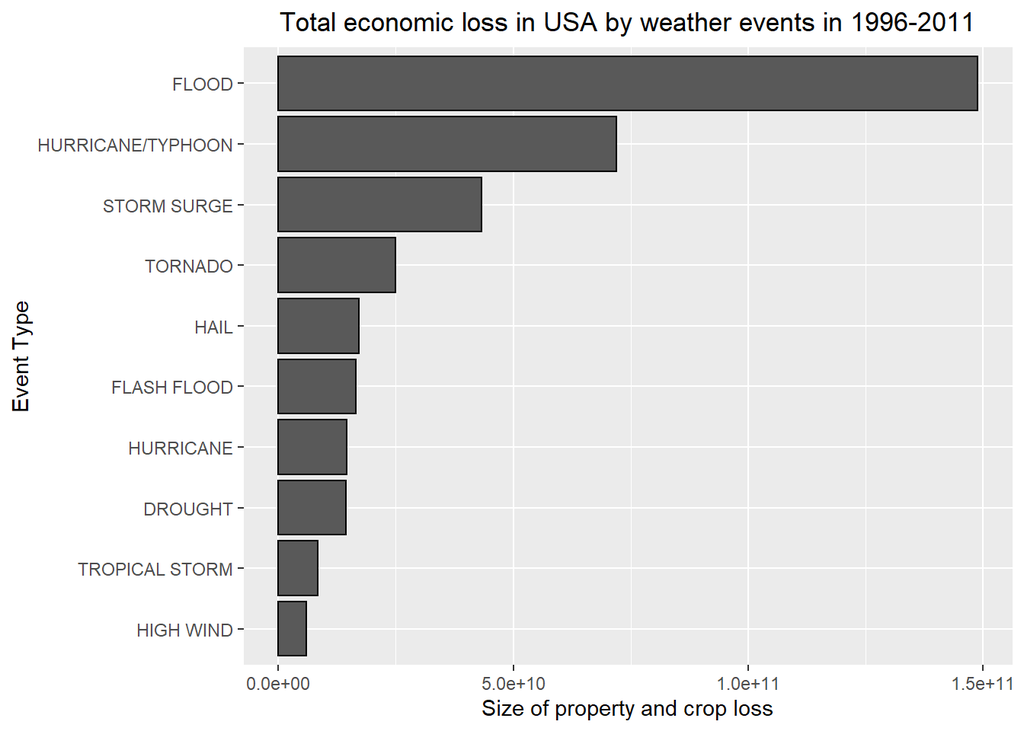

```r
#plotting economic loss
g <- ggplot(data = Top10_events_economy, aes(x = reorder(EVTYPE, ECONOMIC_LOSS), y = ECONOMIC_LOSS))
g <- g + geom_bar(stat = "identity", colour = "black")
g <- g + labs(title = "Total economic loss in USA by weather events in 1996-2011")
g <- g + theme(plot.title = element_text(hjust = 0.5))
g <- g + labs(y = "Size of property and crop loss", x = "Event Type")
g <- g + coord_flip()
print(g)
```